# Situação das Empresas Egressas da Incubadora — UFAL

Análise a partir de dados de CNPJ (Receita Federal / Base dos Dados)

Data de Publicação

27 de julho de 2026

**Mostrar código**

```r
library(readr)
library(dplyr)
library(tidyr)
library(stringr)
library(ggplot2)
library(scales)
library(gt)
```

## 1 Objetivo

Apresentar a **situação cadastral atual** (Ativa, Suspensa, Inapta, Baixada ou Nula perante a Receita Federal) das empresas que passaram pela incubadora da UFAL, a partir dos dados de CNPJ extraídos via [Base dos Dados](https://basedosdados.org/), complementados pelo quadro societário, pelo **motivo e data da situação cadastral**, pelo **CNAE fiscal** (setor de atuação) e pela **opção por Simples Nacional/MEI** de cada empresa.

## 2 Importação dos dados

**Mostrar código**

```r
# Ajuste este caminho para o arquivo completo quando disponível
caminho_empresas <- "../data/data_tidy/df_empresas.csv"
# caminho_empresas <- "df_empresas_sample.csv"  # amostra, para validar a análise

# Todos os campos de código/identificação são forçados como caractere para não
# perder zeros à esquerda nem quebrar em joins com os dicionários abaixo.
# cnae_fiscal_secundaria vem como string separada por vírgula (pode ter mais de
# um código por empresa) — mantido como texto e tratado na seção de CNAE.
col_types_empresas <- cols(
  cnpj                      = col_character(),
  razao_social              = col_character(),
  nome_fantasia             = col_character(),
  nome_socio                = col_character(),
  tipo_socio                = col_character(),
  qualificacao_socio        = col_character(),
  capital_social            = col_double(),
  sigla_uf                  = col_character(),
  id_municipio              = col_character(),
  nome_municipio            = col_character(),
  situacao_cadastral        = col_character(),
  data_situacao_cadastral   = col_date(format = ""),
  motivo_situacao_cadastral = col_character(),
  cnae_fiscal_principal     = col_character(),
  cnae_fiscal_secundaria    = col_character(),
  opcao_simples             = col_character(),
  data_opcao_simples        = col_date(format = ""),
  data_exclusao_simples     = col_date(format = ""),
  opcao_mei                 = col_character(),
  data_opcao_mei            = col_date(format = ""),
  data_exclusao_mei         = col_date(format = "")
)

df_empresas <- read_csv(caminho_empresas, col_types = col_types_empresas)
```

## 3 Preparação e enriquecimento dos dados

Os campos `situacao_cadastral`, `motivo_situacao_cadastral`, `tipo_socio` e `qualificacao_socio` vêm da Receita Federal como códigos numéricos. Traduzimos os mais comuns para rótulos legíveis usando o [layout de dados abertos do CNPJ](https://www.gov.br/receitafederal/dados/cnpj-metadados.pdf).

**Mostrar código**

```r
situacao_lookup <- tibble(
  situacao_cadastral = c("1", "2", "3", "4", "8"),
  situacao            = c("Nula", "Ativa", "Suspensa", "Inapta", "Baixada")
)

tipo_socio_lookup <- tibble(
  tipo_socio      = c("1", "2", "3"),
  tipo_socio_desc = c("Pessoa Jurídica", "Pessoa Física", "Estrangeiro")
)

# Lista não exaustiva — cobre os códigos mais comuns em empresas de pequeno porte.
# Códigos não mapeados aparecem como "Código NN" em vez de dar erro.
qualificacao_lookup <- tibble(
  qualificacao_socio = c("05", "10", "16", "17", "22", "49", "50", "65"),
  qualificacao_desc  = c("Administrador", "Diretor", "Presidente", "Procurador",
                          "Sócio", "Sócio-Administrador", "Empresário Individual",
                          "Titular")
)

# ATENÇÃO: a tabela oficial de "Motivo Situação Cadastral" tem mais de 60
# códigos, e fontes secundárias divergem entre si sobre o significado de boa
# parte deles. Por segurança, só mapeamos aqui os dois códigos confirmados em
# comprovantes oficiais de CNPJ (código 0, empresas ativas sem motivo
# registrado, e código 1, a extinção voluntária — o motivo mais comum de
# baixa). Qualquer outro código aparece como "Código NN": para uma tradução
# completa e confiável, baixe a tabela oficial (ver seção "Notas técnicas"
# ao final, que já traz o código pronto para isso).
motivo_lookup <- tibble(
  motivo_situacao_cadastral = c("0", "1"),
  motivo_desc = c(
    "Sem motivo (situação regular)",
    "Extinção por encerramento de liquidação voluntária"
  )
)

# Opção pelo Simples Nacional / MEI: 1 = optante atualmente, 0 = não optante
# atualmente (pode já ter sido optante — ver datas de opção/exclusão), NA =
# não informado.
simples_mei_lookup <- tibble(
  opcao = c("1", "0"),
  opcao_desc = c("Sim", "Não")
)

# Cores usadas de forma consistente em todos os gráficos e tabelas do relatório
cores_situacao <- c(
  "Ativa"          = "#2E7D32",
  "Suspensa"       = "#F9A825",
  "Inapta"         = "#EF6C00",
  "Baixada"        = "#C62828",
  "Nula"           = "#616161",
  "Não informado"  = "#9E9E9E"
)

niveis_situacao <- c("Ativa", "Suspensa", "Inapta", "Baixada", "Nula", "Não informado")

fmt_moeda <- label_currency(prefix = "R$ ", big.mark = ".", decimal.mark = ",", accuracy = 1)
```

**Mostrar código**

```r
df_empresas <- df_empresas |>
  left_join(situacao_lookup, by = "situacao_cadastral") |>
  left_join(motivo_lookup, by = "motivo_situacao_cadastral") |>
  left_join(tipo_socio_lookup, by = "tipo_socio") |>
  left_join(qualificacao_lookup, by = "qualificacao_socio") |>
  left_join(simples_mei_lookup, by = c("opcao_simples" = "opcao")) |>
  rename(simples_desc = opcao_desc) |>
  left_join(simples_mei_lookup, by = c("opcao_mei" = "opcao")) |>
  rename(mei_desc = opcao_desc) |>
  mutate(
    situacao      = replace_na(situacao, "Não informado"),
    situacao      = factor(situacao, levels = niveis_situacao),
    motivo_desc   = coalesce(motivo_desc, paste("Código", motivo_situacao_cadastral)),
    motivo_desc   = if_else(is.na(motivo_situacao_cadastral), "Não informado", motivo_desc),
    tipo_socio_desc   = replace_na(tipo_socio_desc, "Não informado"),
    qualificacao_desc = coalesce(qualificacao_desc, paste("Código", qualificacao_socio)),
    simples_desc  = replace_na(simples_desc, "Não informado"),
    mei_desc      = replace_na(mei_desc, "Não informado"),
    # Porte/maturidade fiscal: MEI e Simples têm dinâmica de sobrevivência
    # diferente de empresas do regime normal.
    porte_fiscal = case_when(
      opcao_mei == "1"                    ~ "MEI",
      opcao_simples == "1"                ~ "Simples Nacional",
      opcao_simples == "0" | opcao_mei == "0" ~ "Regime normal / não optante",
      TRUE                                 ~ "Não informado"
    ),
    # Diversificação de atuação: quantos CNAEs secundários a empresa declara
    n_cnaes_secundarios = if_else(
      is.na(cnae_fiscal_secundaria) | cnae_fiscal_secundaria == "",
      0L,
      str_count(cnae_fiscal_secundaria, ",") + 1L
    )
  )

# Resumo do quadro societário por empresa (1 linha por CNPJ)
socios_resumo <- df_empresas |>
  filter(!is.na(nome_socio)) |>
  group_by(cnpj) |>
  summarise(
    n_socios                = n(),
    n_socios_pf             = sum(tipo_socio_desc == "Pessoa Física"),
    n_socios_pj             = sum(tipo_socio_desc == "Pessoa Jurídica"),
    tem_socio_administrador = any(qualificacao_desc == "Sócio-Administrador"),
    nomes_socios            = paste(unique(nome_socio), collapse = "; "),
    .groups = "drop"
  )

# Base única de análise: 1 linha por empresa (estabelecimento + cadastro
# fiscal), com o quadro societário resumido à parte. distinct() garante 1
# linha por CNPJ mesmo que o arquivo completo tenha 1 linha por sócio.
empresas_unicas <- df_empresas |>
  distinct(cnpj, .keep_all = TRUE) |>
  select(-nome_socio, -tipo_socio, -qualificacao_socio, -tipo_socio_desc, -qualificacao_desc)

df_analise <- empresas_unicas |>
  left_join(socios_resumo, by = "cnpj") |>
  mutate(
    n_socios                = replace_na(n_socios, 0),
    n_socios_pf             = replace_na(n_socios_pf, 0),
    n_socios_pj             = replace_na(n_socios_pj, 0),
    tem_socio_administrador = replace_na(tem_socio_administrador, FALSE)
  )
```

## 4 Visão geral

**Mostrar código**

```r
n_total       <- nrow(df_analise)
n_ativa       <- sum(df_analise$situacao == "Ativa")
n_baixada     <- sum(df_analise$situacao == "Baixada")
n_susp_inapta <- sum(df_analise$situacao %in% c("Suspensa", "Inapta"))
n_baixa_voluntaria <- sum(df_analise$situacao == "Baixada" &
                             df_analise$motivo_situacao_cadastral == "1", na.rm = TRUE)
pct_ativa     <- percent(n_ativa / n_total, accuracy = 0.1)
pct_baixada   <- percent(n_baixada / n_total, accuracy = 0.1)
```

Das **28** empresas egressas da incubadora analisadas, **17** (60.7%) seguem com situação cadastral **Ativa**, **11** (39.3%) já tiveram o CNPJ **Baixado** — das quais **11** por encerramento *voluntário* (as demais têm outros motivos, incluindo baixa de ofício; ver a seção “Motivo da situação cadastral” a seguir) — e **0** estão **Suspensas ou Inaptas**, situações recuperáveis mediante regularização junto à Receita Federal.

**Mostrar código**

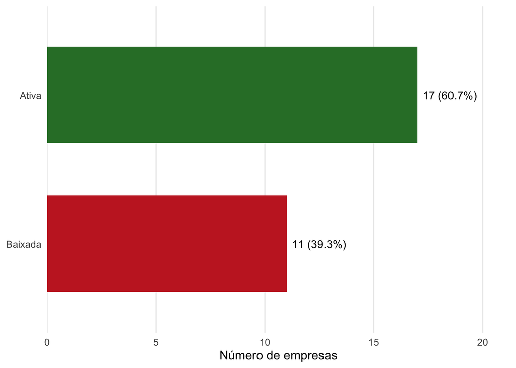

Figura 1: Distribuição das empresas egressas da incubadora por situação cadastral

```r
df_analise |>
  count(situacao, .drop = FALSE) |>
  mutate(pct = n / sum(n)) |>
  filter(n > 0) |>
  ggplot(aes(x = reorder(situacao, n), y = n, fill = situacao)) +
  geom_col(width = 0.65, show.legend = FALSE) +
  geom_text(aes(label = paste0(n, " (", percent(pct, accuracy = 0.1), ")")),
            hjust = -0.1, size = 3.8) +
  scale_fill_manual(values = cores_situacao) +
  scale_y_continuous(expand = expansion(mult = c(0, 0.25))) +
  coord_flip() +
  labs(x = NULL, y = "Número de empresas") +
  theme_minimal(base_size = 12) +
  theme(panel.grid.major.y = element_blank(), panel.grid.minor = element_blank())
```

## 5 Motivo da situação cadastral

Entender *por que* uma empresa saiu do status Ativa é bem diferente de apenas saber que ela saiu: um encerramento voluntário reflete uma decisão dos sócios, enquanto uma baixa ou inaptidão de ofício costuma indicar problemas de regularidade fiscal (omissão de declarações, não localização etc.). Como nem todos os códigos de motivo têm tradução confiável disponível publicamente (ver nota técnica ao final), tratamos aqui apenas as empresas **não ativas**.

**Mostrar código**

```r
df_analise |>
  filter(situacao != "Ativa") |>
  count(situacao, motivo_desc, sort = TRUE) |>
  gt() |>
  tab_header(title = "Motivo declarado, por situação cadastral (empresas não ativas)") |>
  cols_label(situacao = "Situação", motivo_desc = "Motivo", n = "Nº de empresas") |>
  tab_style(style = cell_text(weight = "bold"), locations = cells_column_labels()) |>
  opt_row_striping()
```

Tabela 1

Motivo declarado, por situação cadastral (empresas não ativas)

| Situação | Motivo | Nº de empresas |
| --- | --- | --- |
| Baixada | Extinção por encerramento de liquidação voluntária | 11 |

## 6 Setor de atuação (CNAE)

O CNAE fiscal principal permite segmentar as empresas por setor (tecnologia, saúde, alimentos etc.). Mostramos aqui os códigos mais frequentes; para exibir a descrição de cada CNAE em vez do código, veja a nota técnica ao final.

**Mostrar código**

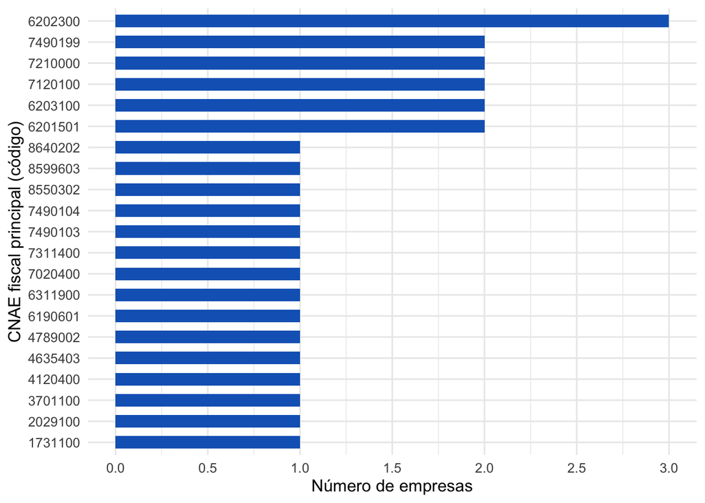

Figura 2: CNAE fiscal principal mais frequente entre as empresas egressas

```r
df_analise |>
  count(cnae_fiscal_principal, sort = TRUE) |>
  filter(!is.na(cnae_fiscal_principal)) |>
  slice_max(n, n = 10) |>
  ggplot(aes(x = reorder(cnae_fiscal_principal, n), y = n)) +
  geom_col(fill = "#1565C0", width = 0.6) +
  scale_y_continuous(breaks = breaks_pretty()) +
  coord_flip() +
  labs(x = "CNAE fiscal principal (código)", y = "Número de empresas") +
  theme_minimal(base_size = 12)
```

A coluna `n_cnaes_secundarios`, calculada no preparo dos dados, indica quantas atividades econômicas secundárias cada empresa declara — uma proxy simples de diversificação de atuação; ela aparece na tabela de detalhamento por empresa, a seguir.

## 7 Porte fiscal: Simples Nacional e MEI

A opção por MEI ou Simples Nacional indica o porte/maturidade fiscal da empresa; MEIs e optantes do Simples tendem a ter dinâmica de sobrevivência diferente de empresas do regime normal.

**Mostrar código**

```r
df_analise |>
  count(porte_fiscal, situacao, .drop = FALSE) |>
  filter(n > 0) |>
  pivot_wider(names_from = situacao, values_from = n, values_fill = 0) |>
  gt() |>
  tab_header(title = "Porte fiscal x situação cadastral") |>
  cols_label(porte_fiscal = "Porte fiscal") |>
  tab_style(style = cell_text(weight = "bold"), locations = cells_column_labels()) |>
  opt_row_striping()
```

Tabela 2: Situação cadastral por porte fiscal

Porte fiscal x situação cadastral

| Porte fiscal | Ativa | Baixada |
| --- | --- | --- |
| Não informado | 3 | 6 |
| Regime normal / não optante | 5 | 5 |
| Simples Nacional | 9 | 0 |

## 8 Detalhamento por empresa

**Mostrar código**

```r
df_analise |>
  arrange(situacao, razao_social) |>
  select(razao_social, nome_fantasia, situacao, motivo_desc, data_situacao_cadastral,
         cnae_fiscal_principal, n_cnaes_secundarios, porte_fiscal, capital_social,
         nome_municipio, sigla_uf, n_socios) |>
  gt() |>
  tab_header(title = "Empresas egressas da incubadora — detalhamento") |>
  fmt_currency(columns = capital_social, currency = "BRL", sep_mark = ".", dec_mark = ",") |>
  cols_label(
    razao_social            = "Razão social",
    nome_fantasia           = "Nome fantasia",
    situacao                = "Situação",
    motivo_desc              = "Motivo",
    data_situacao_cadastral = "Data da situação",
    cnae_fiscal_principal   = "CNAE principal",
    n_cnaes_secundarios      = "Nº CNAEs secund.",
    porte_fiscal             = "Porte fiscal",
    capital_social           = "Capital social",
    nome_municipio           = "Município",
    sigla_uf                 = "UF",
    n_socios                 = "Nº de sócios"
  ) |>
  tab_style(
    style = cell_fill(color = "#C8E6C9"),
    locations = cells_body(columns = situacao, rows = situacao == "Ativa")
  ) |>
  tab_style(
    style = cell_fill(color = "#FFE0B2"),
    locations = cells_body(columns = situacao, rows = situacao %in% c("Suspensa", "Inapta"))
  ) |>
  tab_style(
    style = cell_fill(color = "#FFCDD2"),
    locations = cells_body(columns = situacao, rows = situacao == "Baixada")
  ) |>
  tab_style(
    style = cell_text(weight = "bold"),
    locations = cells_column_labels()
  ) |>
  opt_row_striping() |>
  tab_options(table.font.size = px(12))
```

Tabela 3

Empresas egressas da incubadora — detalhamento

| Razão social | Nome fantasia | Situação | Motivo | Data da situação | CNAE principal | Nº CNAEs secund. | Porte fiscal | Capital social | Município | UF | Nº de sócios |
| --- | --- | --- | --- | --- | --- | --- | --- | --- | --- | --- | --- |
| AMBIMET CONSULT LTDA | AMBIMET CONSULTORIA | Ativa | Sem motivo (situação regular) | 2022-05-24 | 7120100 | 1 | Não informado | R$50.000,00 | Maceió | AL | 3 |
| DESENVOLVIMENTO DE PROGRAMAS, INTERMEDIACAO DE SERVICOS E NEGOCIOS SIRIUS ECOTECH LTDA | SIRIUS ECOTECH | Ativa | Sem motivo (situação regular) | 2020-06-17 | 7490104 | 5 | Regime normal / não optante | R$10.000,00 | Maceió | AL | 4 |
| DMD2 SERVICOS DE TECNOLOGIA DA INFORMACAO LTDA | DMD2 SOLUCOES EM TECNOLOGIA DA INFORMACAO E COMUNICACAO | Ativa | Sem motivo (situação regular) | 2008-05-26 | 6311900 | 5 | Regime normal / não optante | R$5.000,00 | Maceió | AL | 1 |
| ERDMANN AMBIENTAL LTDA | PRISCO AMBIENTAL | Ativa | Sem motivo (situação regular) | 2010-12-22 | 3701100 | 16 | Regime normal / não optante | R$540.000,00 | Maceió | AL | 1 |
| EYEDUC INTELIGENCIA EDUCACIONAL LTDA | EYEDUC | Ativa | Sem motivo (situação regular) | 2012-08-09 | 6202300 | 3 | Simples Nacional | R$20.000,00 | Maceió | AL | 3 |
| I-NET CONSULTORIA E SERVICOS DE INTERNET LTDA | NETPOINT | Ativa | Sem motivo (situação regular) | 2001-01-23 | 6190601 | 10 | Não informado | R$30.000,00 | São Paulo | SP | 1 |
| INTERACTA QUIMICA LTDA | INTERACTA | Ativa | Sem motivo (situação regular) | 2005-11-03 | 2029100 | 0 | Regime normal / não optante | R$50.000,00 | Maceió | AL | 3 |
| LUMEN SERVICOS DE PUBLICIDADE LTDA | LUMEN PUBLICIDADE | Ativa | Sem motivo (situação regular) | 2013-05-09 | 7311400 | 22 | Simples Nacional | R$100.000,00 | Arapiraca | AL | 3 |
| MICELIUM LTDA | MICELIUM | Ativa | Sem motivo (situação regular) | 2022-10-27 | 4789002 | 11 | Simples Nacional | R$15.000,00 | Maceió | AL | 3 |
| MIRAI INOVA SIMPLES (I.S.) | NA | Ativa | Sem motivo (situação regular) | 2025-04-07 | 8550302 | 0 | Simples Nacional | R$0,00 | Maceió | AL | 2 |
| NEXUSBIOTOX INOVA SIMPLES (I.S.) | NA | Ativa | Sem motivo (situação regular) | 2025-03-08 | 7490199 | 2 | Simples Nacional | R$0,00 | Rio Largo | AL | 1 |
| NORVINCO INDUSTRIA DE EMBALAGEM NORDESTE LTDA | NORVINCO | Ativa | Sem motivo (situação regular) | 2005-03-05 | 1731100 | 3 | Não informado | R$1.000.000,00 | Maceió | AL | 2 |
| PYROPHARM LTDA | PYROPHARM | Ativa | Sem motivo (situação regular) | 2022-09-15 | 7210000 | 0 | Simples Nacional | R$10.000,00 | Maceió | AL | 5 |
| RINO SOLUCOES EM TECNOLOGIA LTDA | RINO SOLUCOES EM TECNOLOGIA | Ativa | Sem motivo (situação regular) | 2011-05-27 | 6203100 | 1 | Simples Nacional | R$15.000,00 | Maceió | AL | 1 |
| TOP IDEIAS ANALISE E DESENVOLVIMENTO DE SISTEMAS LTDA | TOP IDEIAS | Ativa | Sem motivo (situação regular) | 2013-10-17 | 6201501 | 0 | Simples Nacional | R$9.000,00 | Marechal Deodoro | AL | 3 |
| VENBRAS TECNOLOGIAS LTDA | VENBRASTECH | Ativa | Sem motivo (situação regular) | 2022-12-14 | 7120100 | 1 | Simples Nacional | R$5.000,00 | Maceió | AL | 3 |
| ZUQ SOLUCOES INTELIGENTES LTDA | ZUQ | Ativa | Sem motivo (situação regular) | 2009-04-28 | 6203100 | 6 | Regime normal / não optante | R$100.000,00 | Maceió | AL | 3 |
| ARC IN LINE - ARQUITETURA CONSTRUCAO CONSULTORIA E PROJETOS LTDA | ARC IN LINE | Baixada | Extinção por encerramento de liquidação voluntária | 2022-08-02 | 4120400 | 47 | Não informado | R$50.000,00 | Maceió | AL | 1 |
| BEM RAIZ - CONSULTORIA EMPRESARIAL LTDA | BEM RAIZ - SUSTENTABILIDADE APLICADA | Baixada | Extinção por encerramento de liquidação voluntária | 2019-04-30 | 7490199 | 4 | Não informado | R$10.000,00 | Maceió | AL | 1 |
| CRAIBEIRA TECNOLOGIA E PESQUISA LTDA | SCISENSE | Baixada | Extinção por encerramento de liquidação voluntária | 2022-08-10 | 7210000 | 5 | Regime normal / não optante | R$6.000,00 | Rio Largo | AL | 5 |
| GIDLE SERVICOS DE LOGISTICA LTDA | GIDLE | Baixada | Extinção por encerramento de liquidação voluntária | 2022-10-06 | 6201501 | 4 | Regime normal / não optante | R$5.000,00 | Maceió | AL | 3 |
| IN OPTIMA CONSULTORIA LTDA | NA | Baixada | Extinção por encerramento de liquidação voluntária | 2018-10-30 | 7020400 | 4 | Não informado | R$10.000,00 | Belo Horizonte | MG | 2 |
| LINKN SOLUCOES INOVADORAS LTDA | LINKN - LINKED KNOWLEDGE | Baixada | Extinção por encerramento de liquidação voluntária | 2023-12-06 | 8599603 | 8 | Regime normal / não optante | R$21.000,00 | Maceió | AL | 3 |
| M A L DOS SANTOS E CIA LTDA | TEC IRRIG | Baixada | Extinção por encerramento de liquidação voluntária | 2017-08-21 | 7490103 | 1 | Não informado | R$15.000,00 | Arapiraca | AL | 4 |
| MEDICA DESENVOLVIMENTO DE APLICATIVOS MEDICOS LTDA | MEDICA APLICATIVOS MEDICOS | Baixada | Extinção por encerramento de liquidação voluntária | 2022-08-25 | 6202300 | 11 | Não informado | R$20.000,00 | Maceió | AL | 2 |
| NUNES E GOES BENEFICIAMENTO E COMERCIO DE BEBIDAS LTDA. | NUNES & GOES BEBIDAS PREMIUM | Baixada | Extinção por encerramento de liquidação voluntária | 2016-12-28 | 4635403 | 2 | Não informado | R$40.000,00 | Maceió | AL | 2 |
| ONCOTARGET - ONCOLOGIA DE PRECISAO LTDA | ONCOTARGET - ONCOLOGIA DE PRECISAO | Baixada | Extinção por encerramento de liquidação voluntária | 2023-01-16 | 8640202 | 0 | Regime normal / não optante | R$3.000,00 | Arapiraca | AL | 4 |
| TWOKNOWBETTER LTDA | NA | Baixada | Extinção por encerramento de liquidação voluntária | 2022-11-29 | 6202300 | 3 | Regime normal / não optante | R$100.000,00 | Maceió | AL | 4 |

## 9 Capital social por situação

**Mostrar código**

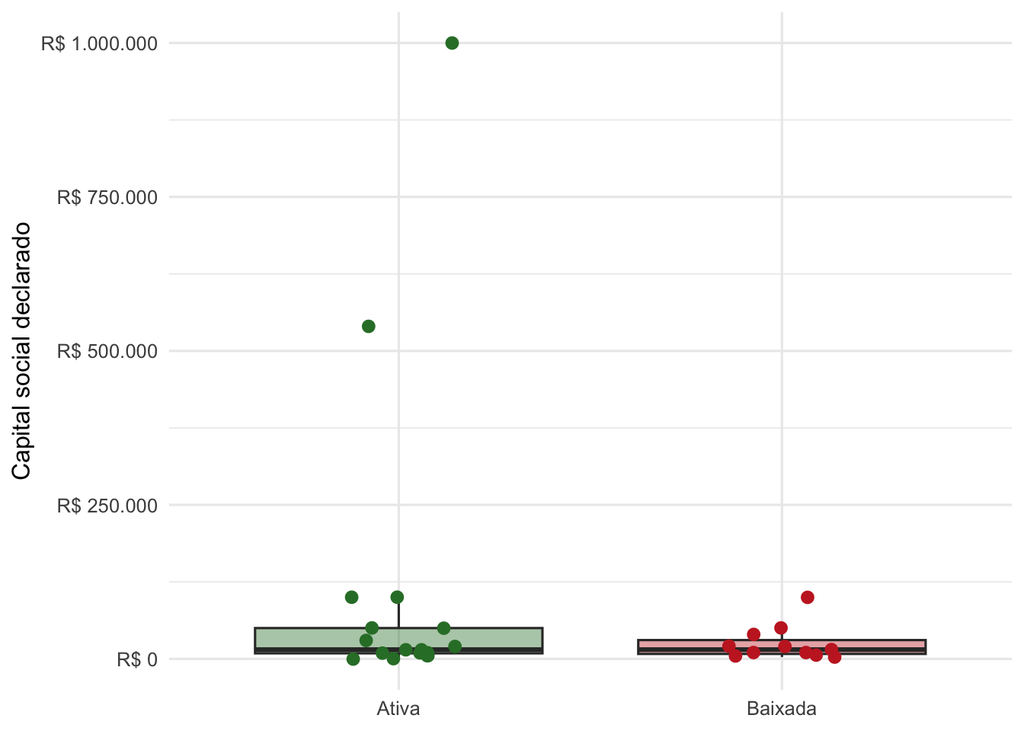

Figura 3: Capital social declarado, por situação cadastral

```r
ggplot(df_analise, aes(x = situacao, y = capital_social)) +
  geom_boxplot(aes(fill = situacao), alpha = 0.4, outlier.shape = NA, show.legend = FALSE) +
  geom_jitter(aes(color = situacao), width = 0.15, size = 2.4, show.legend = FALSE) +
  scale_y_continuous(labels = fmt_moeda) +
  scale_fill_manual(values = cores_situacao, drop = TRUE) +
  scale_color_manual(values = cores_situacao, drop = TRUE) +
  labs(x = NULL, y = "Capital social declarado") +
  theme_minimal(base_size = 12)
```

## 10 Quadro societário

**Mostrar código**

```r
df_analise |>
  select(razao_social, situacao, n_socios, n_socios_pf, n_socios_pj, tem_socio_administrador) |>
  arrange(desc(n_socios)) |>
  mutate(tem_socio_administrador = if_else(tem_socio_administrador, "Sim", "Não")) |>
  gt() |>
  tab_header(title = "Sócios por empresa") |>
  cols_label(
    razao_social             = "Empresa",
    situacao                 = "Situação",
    n_socios                 = "Total de sócios",
    n_socios_pf               = "Pessoa física",
    n_socios_pj               = "Pessoa jurídica",
    tem_socio_administrador  = "Possui sócio-administrador?"
  ) |>
  opt_row_striping()
```

Tabela 4

Sócios por empresa

| Empresa | Situação | Total de sócios | Pessoa física | Pessoa jurídica | Possui sócio-administrador? |
| --- | --- | --- | --- | --- | --- |
| CRAIBEIRA TECNOLOGIA E PESQUISA LTDA | Baixada | 5 | 5 | 0 | Sim |
| PYROPHARM LTDA | Ativa | 5 | 5 | 0 | Sim |
| TWOKNOWBETTER LTDA | Baixada | 4 | 4 | 0 | Sim |
| M A L DOS SANTOS E CIA LTDA | Baixada | 4 | 4 | 0 | Sim |
| ONCOTARGET - ONCOLOGIA DE PRECISAO LTDA | Baixada | 4 | 4 | 0 | Sim |
| DESENVOLVIMENTO DE PROGRAMAS, INTERMEDIACAO DE SERVICOS E NEGOCIOS SIRIUS ECOTECH LTDA | Ativa | 4 | 4 | 0 | Sim |
| LUMEN SERVICOS DE PUBLICIDADE LTDA | Ativa | 3 | 3 | 0 | Sim |
| GIDLE SERVICOS DE LOGISTICA LTDA | Baixada | 3 | 3 | 0 | Sim |
| ZUQ SOLUCOES INTELIGENTES LTDA | Ativa | 3 | 3 | 0 | Sim |
| VENBRAS TECNOLOGIAS LTDA | Ativa | 3 | 3 | 0 | Sim |
| LINKN SOLUCOES INOVADORAS LTDA | Baixada | 3 | 3 | 0 | Sim |
| INTERACTA QUIMICA LTDA | Ativa | 3 | 3 | 0 | Sim |
| MICELIUM LTDA | Ativa | 3 | 3 | 0 | Sim |
| AMBIMET CONSULT LTDA | Ativa | 3 | 2 | 1 | Não |
| EYEDUC INTELIGENCIA EDUCACIONAL LTDA | Ativa | 3 | 3 | 0 | Sim |
| TOP IDEIAS ANALISE E DESENVOLVIMENTO DE SISTEMAS LTDA | Ativa | 3 | 3 | 0 | Sim |
| NORVINCO INDUSTRIA DE EMBALAGEM NORDESTE LTDA | Ativa | 2 | 2 | 0 | Sim |
| IN OPTIMA CONSULTORIA LTDA | Baixada | 2 | 2 | 0 | Sim |
| MIRAI INOVA SIMPLES (I.S.) | Ativa | 2 | 2 | 0 | Não |
| NUNES E GOES BENEFICIAMENTO E COMERCIO DE BEBIDAS LTDA. | Baixada | 2 | 2 | 0 | Sim |
| MEDICA DESENVOLVIMENTO DE APLICATIVOS MEDICOS LTDA | Baixada | 2 | 2 | 0 | Sim |
| RINO SOLUCOES EM TECNOLOGIA LTDA | Ativa | 1 | 1 | 0 | Sim |
| ARC IN LINE - ARQUITETURA CONSTRUCAO CONSULTORIA E PROJETOS LTDA | Baixada | 1 | 1 | 0 | Sim |
| I-NET CONSULTORIA E SERVICOS DE INTERNET LTDA | Ativa | 1 | 1 | 0 | Sim |
| DMD2 SERVICOS DE TECNOLOGIA DA INFORMACAO LTDA | Ativa | 1 | 1 | 0 | Sim |
| BEM RAIZ - CONSULTORIA EMPRESARIAL LTDA | Baixada | 1 | 1 | 0 | Sim |
| ERDMANN AMBIENTAL LTDA | Ativa | 1 | 1 | 0 | Sim |
| NEXUSBIOTOX INOVA SIMPLES (I.S.) | Ativa | 1 | 1 | 0 | Não |

## 11 Distribuição geográfica

**Mostrar código**

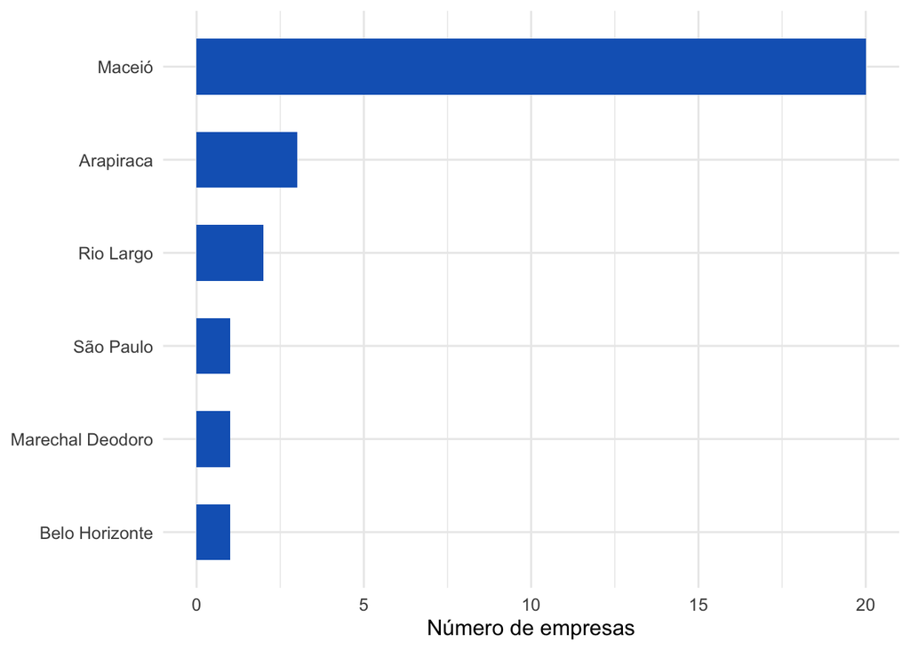

Figura 4: Empresas egressas por município

```r
df_analise |>
  count(nome_municipio, sort = TRUE) |>
  filter(!is.na(nome_municipio)) |>
  ggplot(aes(x = reorder(nome_municipio, n), y = n)) +
  geom_col(fill = "#1565C0", width = 0.6) +
  scale_y_continuous(breaks = breaks_pretty()) +
  coord_flip() +
  labs(x = NULL, y = "Número de empresas") +
  theme_minimal(base_size = 12)
```

## 12 Limitações desta análise

- **Amostra pequena**: o arquivo usado aqui tem poucas empresas, o que não reflete a base completa da incubadora.
- **Foto única no tempo**: `situacao_cadastral` reflete a data da consulta (`data` na tabela do Base dos Dados), não o histórico. Uma empresa “Suspensa” hoje pode ter sido “Ativa” por anos.
- **Tradução parcial do motivo da situação cadastral**: só mapeamos os dois códigos mais comuns e mais bem documentados (0 e 1); os demais aparecem como “Código NN” até que a tabela oficial completa seja incorporada (ver nota técnica).
- **Sem vínculo direto com o programa de incubação**: os dados de CNPJ não indicam data de entrada/saída da incubadora, turma, área de atuação ou tipo de acompanhamento recebido — isso precisa vir de um cadastro interno da incubadora.
- **RAIS/CAGED não são join-áveis por CNPJ**: os microdados públicos de vínculos empregatícios (RAIS/CAGED) são anonimizados pelo MTE e não têm coluna de CNPJ; qualquer cruzamento com emprego só é possível como *proxy* por CNAE/município (ver script de consulta).

## 13 Sugestões de dados adicionais para melhorar a análise

**Mostrar código**

```r
tibble(
  dado = c(
    "Datas de entrada e saída da incubadora (turma/cohort)",
    "Vínculos empregatícios (RAIS/CAGED)",
    "Taxa de sobrevivência empresarial de referência (SEBRAE/IBGE)",
    "Dados internos da incubadora (mentoria, capital captado, prêmios, se é spin-off de pesquisa)"
  ),
  porque = c(
    "Permite calcular tempo de sobrevivência pós-incubação e comparar turmas entre si — hoje só existe um retrato estático.",
    "Mede impacto econômico real (empregos gerados) além da situação cadastral — mas só é viável como proxy setorial/regional, já que os microdados públicos não trazem CNPJ.",
    "Contextualiza se a taxa de sobrevivência das empresas incubadas é melhor ou pior que a média do mercado no mesmo período/UF.",
    "É o dado que mais falta: liga a situação cadastral ao histórico *dentro* da incubadora (mentoria recebida, captação, se ainda está no programa)."
  ),
  fonte = c(
    "Cadastro interno da incubadora da UFAL",
    "Datasets `br_me_rais` e `br_me_caged` no Base dos Dados (nível CNAE/município, não CNPJ)",
    "Estudos públicos do SEBRAE sobre sobrevivência de empresas no Brasil/Alagoas",
    "Cadastro interno da incubadora da UFAL"
  )
) |>
  gt() |>
  tab_header(title = "Dados que agregariam mais valor à análise") |>
  cols_label(dado = "Dado adicional", porque = "Por que ajuda", fonte = "Onde obter") |>
  tab_style(style = cell_text(weight = "bold"), locations = cells_column_labels()) |>
  cols_width(dado ~ px(220), porque ~ px(360), fonte ~ px(220)) |>
  opt_row_striping()
```

Tabela 5

Dados que agregariam mais valor à análise

| Dado adicional | Por que ajuda | Onde obter |
| --- | --- | --- |
| Datas de entrada e saída da incubadora (turma/cohort) | Permite calcular tempo de sobrevivência pós-incubação e comparar turmas entre si — hoje só existe um retrato estático. | Cadastro interno da incubadora da UFAL |
| Vínculos empregatícios (RAIS/CAGED) | Mede impacto econômico real (empregos gerados) além da situação cadastral — mas só é viável como proxy setorial/regional, já que os microdados públicos não trazem CNPJ. | Datasets `br_me_rais` e `br_me_caged` no Base dos Dados (nível CNAE/município, não CNPJ) |
| Taxa de sobrevivência empresarial de referência (SEBRAE/IBGE) | Contextualiza se a taxa de sobrevivência das empresas incubadas é melhor ou pior que a média do mercado no mesmo período/UF. | Estudos públicos do SEBRAE sobre sobrevivência de empresas no Brasil/Alagoas |
| Dados internos da incubadora (mentoria, capital captado, prêmios, se é spin-off de pesquisa) | É o dado que mais falta: liga a situação cadastral ao histórico *dentro* da incubadora (mentoria recebida, captação, se ainda está no programa). | Cadastro interno da incubadora da UFAL |

**DicaNotas técnicas: traduções completas de motivo e CNAE**

Os lookups usados neste relatório para `motivo_situacao_cadastral` (e, se desejar, para `cnae_fiscal_principal`) são propositalmente parciais, porque fontes secundárias divergem sobre boa parte dos códigos menos comuns. A Receita Federal distribui as tabelas de domínio completas e oficiais junto com os Dados Abertos do CNPJ — os arquivos `Motivos.zip` e `Cnaes.zip`. O código abaixo baixa e junta essas tabelas automaticamente (ajuste o mês/ano da pasta para a competência mais recente disponível em https://arquivos.receitafederal.gov.br/dados/cnpj/dados_abertos_cnpj/).

**Mostrar código**

```r
competencia <- "2025-05"  # ajuste para a pasta mais recente disponível
base_url <- paste0("https://arquivos.receitafederal.gov.br/dados/cnpj/dados_abertos_cnpj/",
                    competencia, "/")

baixar_tabela_dominio <- function(nome_arquivo, col_names) {
  destino_zip <- tempfile(fileext = ".zip")
  download.file(paste0(base_url, nome_arquivo), destino_zip, mode = "wb")
  arquivo <- unzip(destino_zip, exdir = tempdir())
  read_delim(
    arquivo, delim = ";", locale = locale(encoding = "Latin1"),
    col_names = col_names,
    col_types = cols(.default = col_character())
  )
}

motivos_oficial <- baixar_tabela_dominio("Motivos.zip", c("motivo_situacao_cadastral", "motivo_desc_oficial"))
cnaes_oficial   <- baixar_tabela_dominio("Cnaes.zip",   c("cnae_fiscal_principal", "cnae_desc_oficial"))

df_empresas <- df_empresas |>
  left_join(motivos_oficial, by = "motivo_situacao_cadastral") |>
  left_join(cnaes_oficial,   by = "cnae_fiscal_principal")
```

Depois de rodar, substitua `motivo_desc`/`cnae_fiscal_principal` pelas colunas `motivo_desc_oficial`/`cnae_desc_oficial` nos chunks `tbl-motivo` e `fig-cnae` para usar a tradução completa e oficial em vez dos lookups parciais definidos no chunk `dicionarios`.